# Exploration of Pittsburgh Arrest and Allegheny County Jail Data

Devraj Kori

5/29/2020

## Mapping Pittsburgh arrest patterns against area black population

In the map below, the circle markers indicate the approximate locations of arrests in Pittsburgh since the start of 2019, and the area shading shows the share of the area population that is black/African-American. Arrests for non-violent offenses tend to be concentrated in areas of Pittsburgh with large black populations including the Hill District, East Liberty, and Homewood.

[interactive chart not shown]

## Racial disparities in non-violent youth arrests

The markers below show the arrests of individuals who were 21 or younger at the time of arrest for non-violent offenses since the start of 2019 ,color-coded by race. Black youths are funneled into the criminal justice system for minor offenses, reducing the legal opportunities available to them for the rest of their lives and perpetuating cycles of poverty.

[interactive chart not shown]

## Violent share of arrests by race

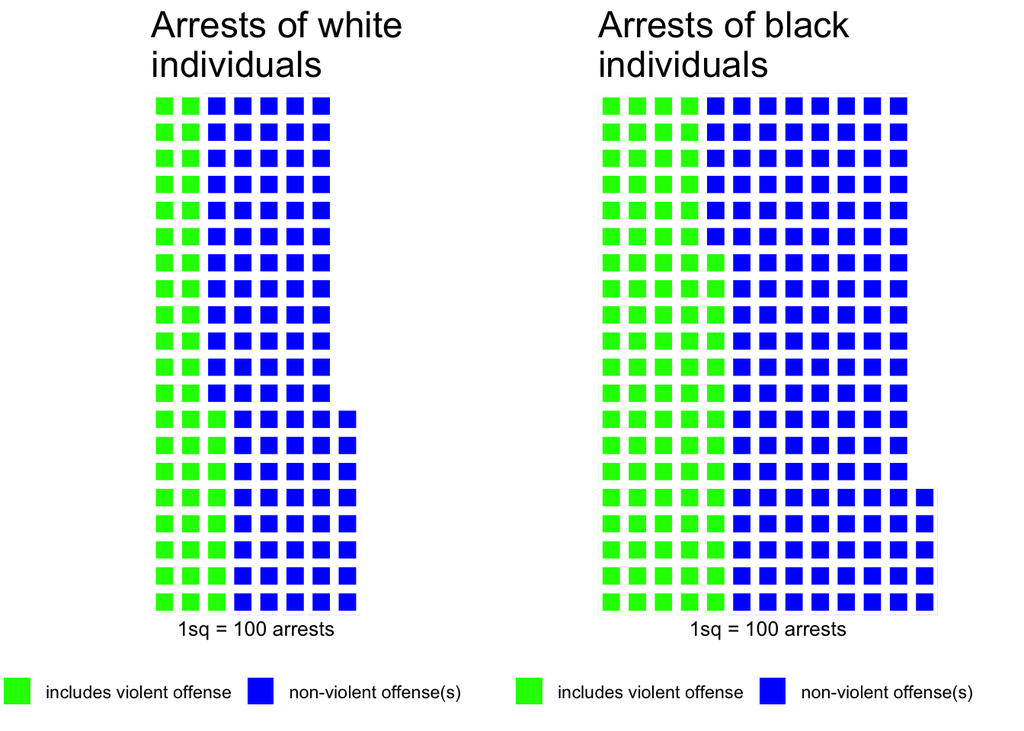

## Jail population over time by race

The racial breakdown of the population of Allegheny County Jail has remained fairly constant over time. Black individuals make up less than 15% of Allegheny County’s population, but make up over 50% of the jail population.

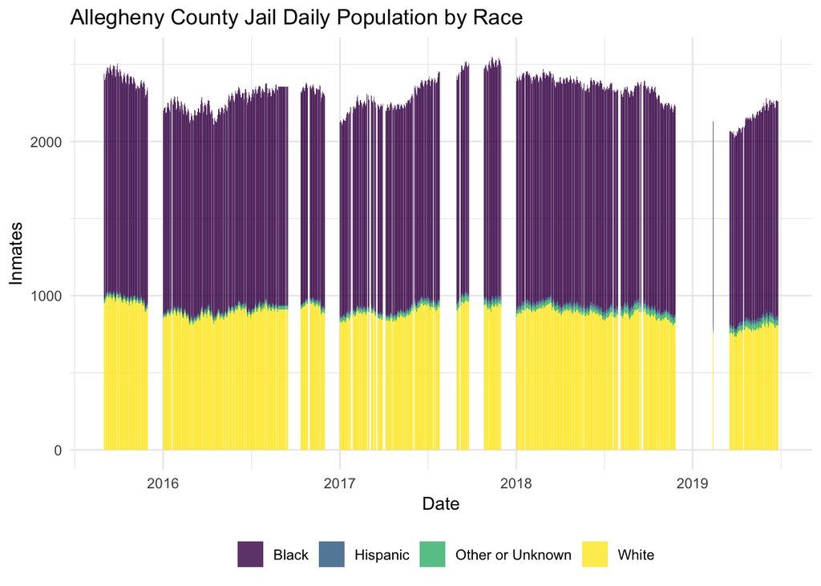

## Average estimated length of stay (years) by race for Allegheny County Jail inmates.

[figure not shown]

## Distribution of ages of inmates of Allegheny County Jail.

The modal black inmate is in their early to to mid 20s, and black inmates tend to be a few years younger than their white counterparts across the distribution.

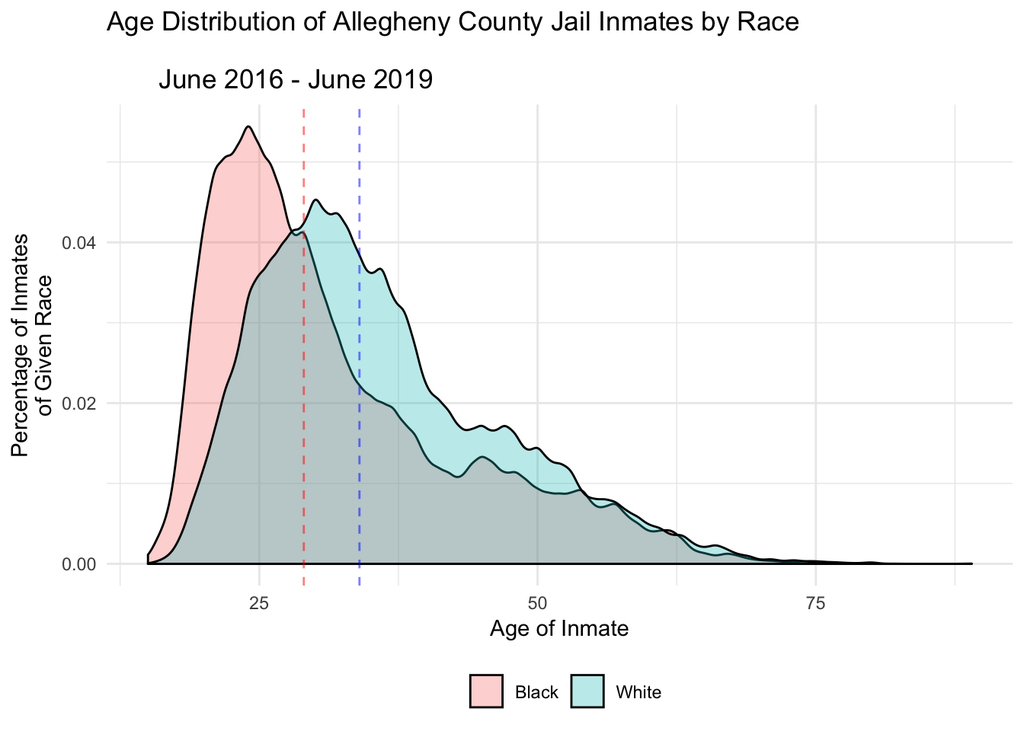